# 1-ый этап индивидуального проекта

Операционные системы

Верниковская Е. А., НПИбд-01-23

Российский университет дружбы народов, Москва, Россия

28 февраля 2024

# Вводная часть

## Цель работы

Научиться размещать на Github pages заготовки для пресонального сайта

## Задание

1. Установить необходимое программное обеспечение.
2. Скачать шаблон темы сайта.
3. Разместить его на хостинге git.
4. Установить параметр для URLs сайта.
5. Разместить заготовку сайта на Github pages.

# Выполнение 1-ого этапа индивидуального проекта

## Установка необходимого ПО

Скачиваем последнюю версию исполняемого файла hugo для своей ОС (рис. 1)

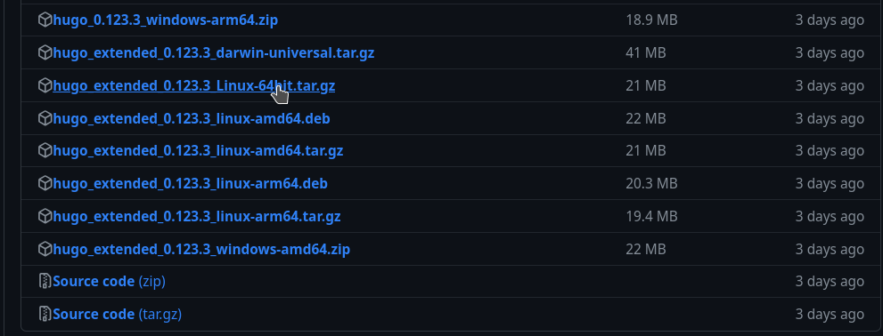

Скачивание файла

## Установка необходимого ПО

Переходим в папку Загрузки и распаковывем архив с исполняемым файлом, введя *tar -xvf* (рис. 2)

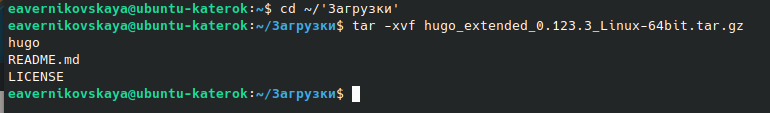

Распаковка архива

## Установка необходимого ПО

Далее переходим в домашний каталог и создаём папку bin, с помощью *mkdir* (рис. 3)

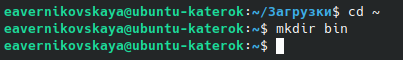

Создание bin

## Установка необходимого ПО

Переносим в папку bin исполняемый файл hugo, с помощью команды *mv* (рис. 4)

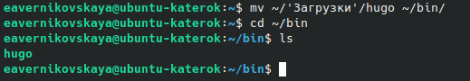

Перенос файла

## Скачивание шаблона темы сайта

- Создаём свой репозиторий на основе репозитория с шаблоном темы сайта (рис. 5)

[figure not shown]

Репозиторий blog

## Скачивание шаблона темы сайта

Переходим в каталог ~/work и клонируем созданный репозиторий к себе в локальный репозиторий, введя *git clone –recursive* (рис. 6)

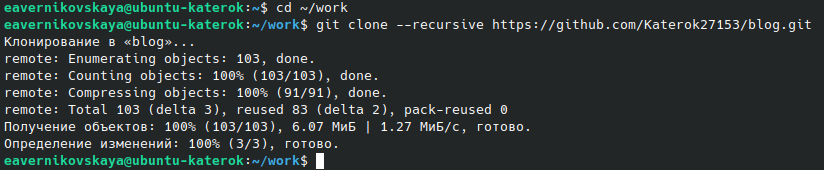

Клонирование blog

## Скачивание шаблона темы сайта

Запускаем исполняемый файл, введя *~/bin/hugo server* (рис. 7)

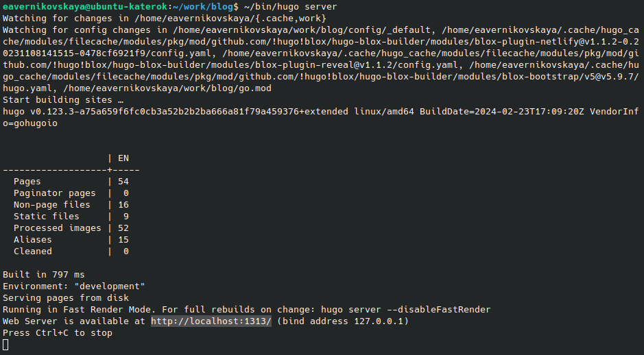

Запуск исполняемого файла

## Скачивание шаблона темы сайта

Копируем ссылку (выделена на предыдцщем скриншоте) и переходим на страничку сайта на локальном сервере (рис. 8)

[figure not shown]

Страничка сайта на локальном сервере

## Установка параметра для URLs сайта

Создаём новый пустой репозиторий с именем Katerok27153.github.io (имя репозитория будет адресом сайта) (рис. 9)

[figure not shown]

Создание нового репозитория

## Установка параметра для URLs сайта

В каталоге work клонируем созданный репозиторий, чтобы создать локальный репозиторий у себя на компьютере (рис. 10)

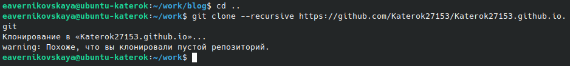

Клонирование Katerok27153.github.io

## Установка параметра для URLs сайта

Далее переходим в созданный новый каталог и создаём главную ветку с именем main, с помощью команды *git checkout -b main* (рис. 11)

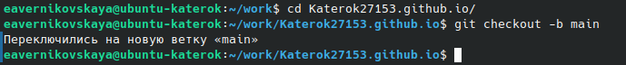

Создание ветки

## Установка параметра для URLs сайта

Создаём пустой файл README.md и отправляем изменения на глобальный репозиторий, чтобы активировать его (рис. 12)

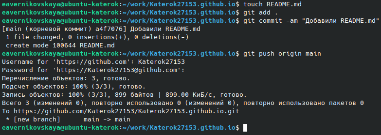

Создание файла + отправка на git

## Установка параметра для URLs сайта

В файле .gitignore отключаем public, чтобы каталоги с таким названием не игнорировались (рис. 13)

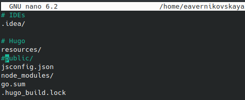

Редактирование файла .gitignore

## Установка параметра для URLs сайта

Подключаем репозиторий к каталогу public (рис. 14)

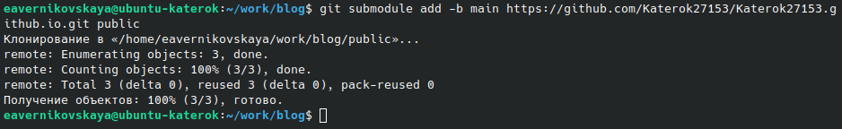

Подключение репозитория к public

## Установка параметра для URLs сайта

Далее запускаем исполняемый файл, с помощью *~/bin/hugo*, чтобы заполнить создавшийся public (рис. 15)

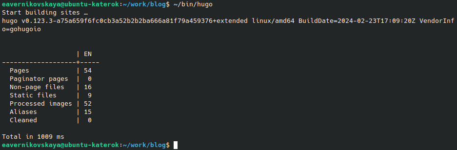

Запуск hugo

## Размещение загатовки файла на Github pages

Проверяем есть ли подключение между public и репозиторием Katerok27153.github.io (рис. 16)

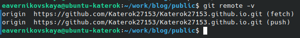

Проверка

## Размещение загатовки файла на Github pages

Отправляем изменения на глобальный репозиторий, с помощью *git add .*, *git commit -am* и *git push* (рис. 17)

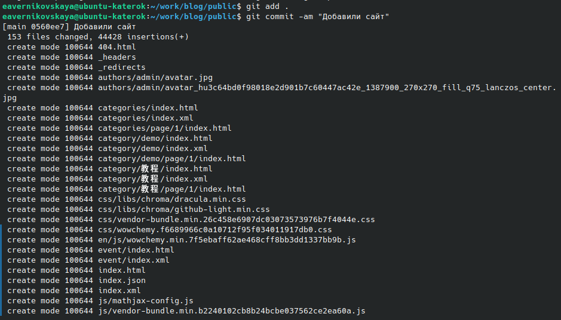

Сохранение изменений и комментирование

## Размещение загатовки файла на Github pages

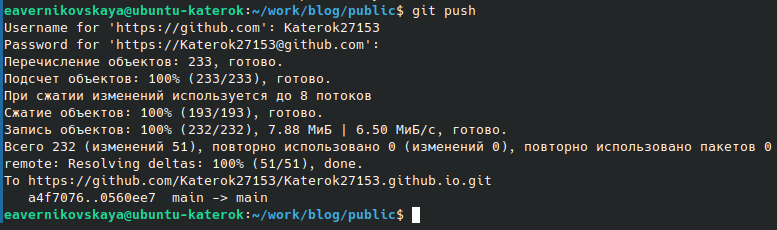

Отправка на git

## Размещение загатовки файла на Github pages

- Копируем ссылку на наш новый сайт (имя репозитория, в нашем случаем Katerok27153.github.io) и переходим на него (рис. 19)
- Всё получилось!!!

[figure not shown]

Наш сайт

# Выводы

В ходе выполнения 1-ого этапа индивидуального проекта мы научились размещать на Github pages заготовки для персонального сайта